# R Study Note

Ruidi Zhao’s R study note.

# Lab: Introduction to R

## Useful commands

```r
getwd()
```

```
[1] "/Users/zhaoruidi/Documents/R_Learning/Note"
```

## Basic Calculation

```r
5%%2 # Python: %
```

```
[1] 1
```

```r
2^3 # Python: **
```

```
[1] 8
```

## Vector

```r
x <- c(1,2,3,4)
y <- c(3,4,5,6)
```

`ls()` is used to look at a list of all of the objects  
`rm()` is used to delete any that we don’t wat

```r
ls()
```

```
 [1] "A"          "abs2"       "abs3"       "books"      "factorial2" "fib"
 [7] "isPrime"    "mean2"      "name"       "square"     "x"          "y"
```

```r
rm(x, y)
ls()
```

```
 [1] "A"          "abs2"       "abs3"       "books"      "factorial2" "fib"
 [7] "isPrime"    "mean2"      "name"       "square"
```

```r
rm(list=ls()) # remove everything at once
```

## List

```r
x <- list(1:3, TRUE, 'Hello', list(1:2, 5))
```

## Matrix

```r
x = matrix(data = c(1,2,3,4), nrow = 2, ncol = 2)
x
```

```
     [,1] [,2]
[1,]    1    3
[2,]    2    4
```

`byrow`的话就是按照row的方向排element

```r
matrix(c(1,2,3,4), 2, 2, byrow = TRUE)
```

```
     [,1] [,2]
[1,]    1    2
[2,]    3    4
```

## DataFrame

```r
books <- data.frame(author = c("Ripley", 'Cox', 'Snijders', 'Cox'),
                    year = c(1980, 1979, 1999, 2006),
                    publihser = c('Wiley', "Chapman", "Sage", "CUP"))
books
```

| author | year | publihser |
| --- | --- | --- |
| Ripley | 1980 | Wiley |
| Cox | 1979 | Chapman |
| Snijders | 1999 | Sage |
| Cox | 2006 | CUP |

## Function

```r
setdiff
```

```
function (x, y)
{
    x <- as.vector(x)
    y <- as.vector(y)
    unique(if (length(x) || length(y))
        x[match(x, y, 0L) == 0L]
    else x)
}
<bytecode: 0x7ff9fe836b30>
<environment: namespace:base>
```

```r
args(setdiff) # Get the arguments for function
```

```
function (x, y)
NULL
```

### Writing Functions

```r
square = function(x) {
  x^2
}
square(4)
```

```
[1] 16
```

```r
mean2 <- function(x) {
  n <- length(x)
  sum(x)/n
}
mean2(1:10)
```

```
[1] 5.5
```

### `for()` Loops

```r
factorial2 = function(n) {
  out = 1

  for (i in 1:n) {
    out = out * i
  }

  out
}
factorial2(10)
```

```
[1] 3628800
```

也可以不用在function外面

```r
for (name in 1:4)
  print(name)
```

```
[1] 1
[1] 2
[1] 3
[1] 4
```

### Conditional Code

```r
abs2 = function(x) {
  if (x < 0) out = -x
  else out = x
  out
}
abs2(-4)
```

```
[1] 4
```

Or you can use `ifelse()`

```r
abs3 = function(x) {
  ifelse(x < 0, -x, x)
}
abs3(2)
```

```
[1] 2
```

```r
abs3(-3)
```

```
[1] 3
```

`while()` loops

```r
isPrime = function(n){
  i = 2
  if (n < 2) return(FALSE)

  while (i < sqrt(n)) {
    if (n%%i == 0) return(FALSE)
    i = i + 1
  }
  return(TRUE) # 注意return后面一定要加上括号
}
isPrime(10)
```

```
[1] FALSE
```

```r
isPrime(37)
```

```
[1] TRUE
```

### Recursion

```r
fib = function(n) {
  if (n<2) return(1)
  else return(fib(n-1) + fib(n-2))
}
fib(10) # 斐波那契数列
```

```
[1] 89
```

### `apply()`

If we want to perform a function on every row or column in a matrix (or array), we can use the `apply()` function. The syntax is apply(x, d, f), which will apply the function f to each of the dth dimension of x.If d = 1 this corresponds to rows, and d = 2 to the columns of a matrix. 这个d不就跟python的axis差不多？

```r
A = cbind(1:10, (1:10)^2, (1:10)^3)
apply(A, 2, sum) # calculate the sum of all columns
```

```
[1]   55  385 3025
```

It will also work for the matrix-like objects, such as data frames.

```r
library(MASS)
apply(hills, 2, mean)
```

```
       dist       climb        time
   7.528571 1815.314286   57.875714
```

```r
apply(hills, 2, sd)
```

```
       dist       climb        time
   5.523936 1619.150536   50.040716
```

## Random Variables

```r
# set.seed(0)
# So that you can reproduce the result

x = rnorm(50,mean = 0, sd = 1)
y = x + rnorm(50, mean = 50, sd = 0.1)
cor(x, y) # Get the correlation between x and y
```

```
[1] 0.9935414
```

```r
var(x)
```

```
[1] 0.8129309
```

```r
sd(x)
```

```
[1] 0.9016268
```

```r
mu = c(-2, -1, 0, 1, 2)
out = lapply(mu, function(x) rnorm(100, mean = x))
lapply(out, mean)
```

```
[[1]]
[1] -1.980254

[[2]]
[1] -1.027975

[[3]]
[1] 0.07192967

[[4]]
[1] 1.004284

[[5]]
[1] 2.108529
```

If we want the result to be a vector

```r
sapply(out, mean) #除了这个sapply和lapply都是一样的
```

```
[1] -1.98025398 -1.02797480  0.07192967  1.00428354  2.10852940
```

### `replicate()`

Sometimes we wish to repeat exactly the same operation multiple times, without having a different input (this is typically used in conjunction with the generation of random numbers)

```r
out = replicate(20, rnorm(100), simplify = FALSE)
# out is a list of 20 independent data sets, each consisting of 100 standard normal random variables
```

### `tapply()`

Evaluate a function on data in a vector of list which are *grouped* according to the levels of some other factor. For example,

```r
library(MASS)
head(genotype)
```

|  | Litter | Mother | Wt |
| --- | --- | --- | --- |
| 1 | A | A | 61.5 |
| 2 | A | A | 68.2 |
| 3 | A | A | 64.0 |
| 4 | A | A | 65.0 |
| 5 | A | A | 59.7 |
| 6 | A | B | 55.0 |

```r
with(genotype, tapply(Wt, Mother, mean))
```

```
      A       B       I       J
55.4000 58.7000 53.3625 48.6800
```

```r
# group according to the value of Mother
# with(genotype, tapply(Wt, Mother, summary))
```

It is also possible to provide more than one grouping in the form of a list of data frame, in which case the data are broken down by both:

```r
tapply(genotype$Wt, genotype[,1:2], mean)
```

```
      Mother
Litter      A        B        I        J
     A 63.680 52.40000 54.12500 48.96000
     B 52.325 60.64000 53.92500 45.90000
     I 47.100 64.36667 51.60000 49.43333
     J 54.350 56.10000 54.53333 49.06000
```

### `mapply()`

Sometimes it may be useful to apply a function of several arguments repeatedly, where more than one argument can change.

```r
mapply(seq, from = c(1,4,-3), to = c(2,9,0), by = 0.5)
```

```
[[1]]
[1] 1.0 1.5 2.0

[[2]]
 [1] 4.0 4.5 5.0 5.5 6.0 6.5 7.0 7.5 8.0 8.5 9.0

[[3]]
[1] -3.0 -2.5 -2.0 -1.5 -1.0 -0.5  0.0
```

```r
# 1, 2
# 4, 9
# -3, 0
```

## Arrays and Tables

```r
occupationalStatus
```

```
      destination
origin   1   2   3   4   5   6   7   8
     1  50  19  26   8   7  11   6   2
     2  16  40  34  18  11  20   8   3
     3  12  35  65  66  35  88  23  21
     4  11  20  58 110  40 183  64  32
     5   2   8  12  23  25  46  28  12
     6  12  28 102 162  90 554 230 177
     7   0   6  19  40  21 158 143  71
     8   0   3  14  32  15 126  91 106
```

```r
# 如果用dataframe表示的话就是3498行，所以可以用这种 "contingency table"（难道不是pivot table吗？）
```

### Higher Dimensions

Arrays are defined much like matrices, with a call to the `array()` command.

```r
arr = array(1:24, dim = c(2,3,4))
# di就是dimension，所以这边是define了一个2*3*4的array
# 所以就是2行3列，然后有4个这样的东西？
arr
```

```
, , 1

     [,1] [,2] [,3]
[1,]    1    3    5
[2,]    2    4    6

, , 2

     [,1] [,2] [,3]
[1,]    7    9   11
[2,]    8   10   12

, , 3

     [,1] [,2] [,3]
[1,]   13   15   17
[2,]   14   16   18

, , 4

     [,1] [,2] [,3]
[1,]   19   21   23
[2,]   20   22   24
```

```r
dim(arr)
```

```
[1] 2 3 4
```

Note that a 2-dimensional array is identical to a matrix. Arrays can be subsetted and modified in exactly the same way as a matrix, only using the appropriate number of co-ordinates:

```r
arr[1,2,3]
```

```
[1] 15
```

```r
# 1 行 2 列 第三个东西
```

```r
arr[,2,]
```

```
     [,1] [,2] [,3] [,4]
[1,]    3    9   15   21
[2,]    4   10   16   22
```

### Tables

```r
library(MASS)
head(cabbages)
```

|  | Cult | Date | HeadWt | VitC |
| --- | --- | --- | --- | --- |
| 1 | c39 | d16 | 2.5 | 51 |
| 2 | c39 | d16 | 2.2 | 55 |
| 3 | c39 | d16 | 3.1 | 45 |
| 4 | c39 | d16 | 4.3 | 42 |
| 5 | c39 | d16 | 2.5 | 53 |
| 6 | c39 | d16 | 4.3 | 50 |

```r
table(cabbages$Date)
```

```
d16 d20 d21
 20  20  20
```

```r
# 懂了就是table相当于value_counts() in Python
```

```r
table(cabbages[,1:2])
```

```
     Date
Cult  d16 d20 d21
  c39  10  10  10
  c52  10  10  10
```

### Binning the Data

Discretization

```r
# Discretization: group data together into intervals
head(Nile)
```

```
[1] 1120 1160  963 1210 1160 1160
```

```r
bins = c(0, seq(from = 700, to=1300, by=100), Inf) # Inf 就是infinite
bins
```

```
[1]    0  700  800  900 1000 1100 1200 1300  Inf
```

```r
disNile = cut(Nile, bins)
head(disNile)
```

```
[1] (1.1e+03,1.2e+03] (1.1e+03,1.2e+03] (900,1e+03]       (1.2e+03,1.3e+03]
[5] (1.1e+03,1.2e+03] (1.1e+03,1.2e+03]
8 Levels: (0,700] (700,800] (800,900] (900,1e+03] ... (1.3e+03,Inf]
```

```r
table(disNile)
```

```
disNile
          (0,700]         (700,800]         (800,900]       (900,1e+03]
                6                20                25                19
  (1e+03,1.1e+03] (1.1e+03,1.2e+03] (1.2e+03,1.3e+03]     (1.3e+03,Inf]
               12                11                 6                 1
```

```r
# you can adjust the lable
disNile = cut(Nile, bins, labels = bins[-9])
table(disNile)
```

```
disNile
   0  700  800  900 1000 1100 1200 1300
   6   20   25   19   12   11    6    1
```

## Strings

You can send a string to the screen using the `cat()` function.

```r
cat("hello")
```

```
hello
```

```r
"hello" # 如果直接写的话就会有双引号
```

```
[1] "hello"
```

```r
myFunc = function(x) {
  cat("Squaring the number\n") #\n: start a new line
  return(x^2)
}
myFunc(2)
```

```
Squaring the number
[1] 4
```

Use escape character

```r
cat("She said \"Hello\" to the man.\n")
```

```
She said "Hello" to the man.
```

`cat()` also works with number

```r
cat(57, "clouds", "\n")
```

```
57 clouds
```

By default cat() separates the arguments with a space, but you can change this:

```r
cat(57, "clouds", "\n", sep = "")
```

```
57clouds
```

### The `pastes()` function

It’s often useful to be able to stick strings together, for which purpose we have the function `paste()`

```r
paste("Hello", "there")
```

```r
paste("Plan", LETTERS[1:5])
```

```
[1] "Plan A" "Plan B" "Plan C" "Plan D" "Plan E"
```

```r
paste("x", 1:10, sep = '')
```

```
 [1] "x1"  "x2"  "x3"  "x4"  "x5"  "x6"  "x7"  "x8"  "x9"  "x10"
```

```r
paste(LETTERS[1:10])
paste(LETTERS[1:10], collapse = " ")
```

### Other Manipulation

```r
nchar("How long is this string?")
```

```
[1] 24
```

```r
strsplit("separate words are fun", split = " ")
```

```
[[1]]
[1] "separate" "words"    "are"      "fun"
```

```r
substr("I don't want all of this string", 14, 24)
```

```
[1] "all of this"
```

## Graphics

The `plot()` function is the primary way to plot data in R.

```r
x = rnorm(100)
y = rnorm(100)
plot(x, y, xlab = 'x-axis', ylab = 'y-axis', main = 'Plot of X vs Y')
```

save the graph

```r
pdf('Figure.pdf') # save it as pdf
# jpeg('Figure.jpeg') # save it as jpeg
plot(x, y, col = 'green')
dev.off() # Tell R that we are done creating the plot
```

Create contour plot with `contour()`, it takes three arguments: 1. A vector of the x values (the first dimension) 2. A vector of the y values (the second dimension), and 3. A matrix whose elements correspond to the z value (the third dimension) for each pair of (x, y) corrdinates

```r
x = seq(1, 10) # or x = 1:10
y = x
f = outer(x, y, function(x, y)cos(y)/(1 + x^2))
contour(x, y, f)
```

Heatmap

```r
image(x, y, f)
```

Use `persp()`

```r
persp(x, y, f, theta = 30, phi = 20)
# Theta and phi control the angles at which the plot is viewed
```

## Indexing Data

```r
A = matrix(1:16, 4, 4)
A
A[2,3]
```

```r
A[c(1, 3), c(2, 4)] # Select multiple row and column
A[1:3, 2:4]
A[, 1:2]
A[1:2, ]
A[-2, ] # '-' means except
dim(A) # The dimension of A, 就是python里的shape?
```

## Loading Data

For most analyses, the first step involves importing a data set into R.

```r
# Auto = read.table('Auto.data', header = T, na.strings = '?')
# dim(Auto) # return the dimension
# Auto = na.omit(Auto) # remove rows with NA
# names(Auto) # Check the variable names
```

Generate some plot

```r
# plot(Auto$, Auto$)
# # 或者不使用$
# attach(Auto)
# plot(column1, column2) # scatter plot if two numerical
# hist(column1, col = 2) # histogram
# pairs(Auto) # scatter plot matrix
```

Quantitative to Categorical with `as.factor()`

```r
# cylinders = as.factor(cylinders)
```

`summary()` function produces a numerical summary of each variable in a particular data set

```r
# summary(Auto)
```

## Record history

```r
savehistory() # save a record of all of the commands in the most recent session
loadhistory() # load the history next time we use R
```

# Lab: Linear Regression

```r
library(MASS)
library(ISLR)
names(Boston)
lm.fit = lm(medv~lstat, data = Boston) # lm: least square linear regression model
                        # lm(y~x, data)
```

Get information about our linear regression model

```r
lm.fit
summary(lm.fit)
names(lm.fit) # what kind of info are stored?
coef(lm.fit) # get the coefficient; or lm.fit$coefficients
```

Next, we examine some diagnostic plots

```r
par(mfrow = c(2, 2)) # split the screen into 4 parts
plot(lm.fit)
```

```r
plot(predict(lm.fit), residuals(lm.fit))
plot(predict(lm.fit), rstudent(lm.fit))
```

Compute the leverage statistics

```r
plot(hatvalues(lm.fit))
which.max(hatvalues(lm.fit)) # == python idxmax()
```

## Multiple Linear Regression

```r
lm.fit = lm(medv~lstat + age, data = Boston) # 如果是multiple的话格式是lm(y~x1+x2+x3)
summary(lm.fit)
```

If we want to use all variables as the X variables

```r
lm.fit = lm(medv~., data = Boston) # use this short-hand!
summary(lm.fit)
```

What if we would like to perform a regression using all of the variables but one?

```r
lm.fit1 = lm(medv~.-age, data = Boston) # 懂了！就是.-age就好了
summary(lm.fit1)
```

Alternatively, the `update()` function can be used

```r
lm.fit1 = update(lm.fit, ~.-age) #！！
```

## Interaction Terms

```r
summary(lm(medv~lstat*age, data = Boston))
# lstat*age is the short-hand for: lstat + age + lstat: age
```

## Non-linear Transformations of the Predictors

```r
lm.fit2 = lm(medv~lstat + I(lstat^2), data = Boston)
summary(lm.fit2)
```

The near-zero p-value associated with the quadratic term suggests that it leads to an improved model. We use `anova()` function to further quantify the extent to which the quadratic fit is superior to the linear fit.

```r
lm.fit = lm(medv~lstat, data = Boston)
anova(lm.fit, lm.fit2)
```

The `anova()` function performs a hypothesis test comparing the two models. The null hypothesis is that the two models fir the data equally well, and the alternative hypothesis is that the full model is superior. Here, the p-value is near zero, so we favor the alternative hypothesis.

```r
par(mfrow = c(2, 2))
plot(lm.fit2)
# There is little discernible pattern in the residuals
```

We can also do a fifth-order polynomial fit:

```r
lm.fit5 = lm(medv~poly(lstat, 5), data = Boston)
summary(lm.fit5)
```

Or a log transformation

```r
summary(lm(medv~log(rm), data = Boston))
```

## Qualitative Predictors

```r
names(Carseats) # examine the Carseats data
# Try to predict Sales
```

```r
lm.fit = lm(Sales~.+Income:Advertising+Price:Age, data = Carseats)
# 如果有Categorical data, R 自动 dummy variable
summary(lm.fit)
```

The `contrasts()` function returns the coding that R uses for the dummy variables

```r
contrasts(Carseats$ShelveLoc)
# ShelveLocGood & ShelveLocMeidum
# 注意，自动drop_first = True
```

```r
LoadLibraries = function() {
  library(ISIR)
  library(MASS)
  print("The libraries have been loaded.")
}
```

# Lab: Logistic Regression, LDA, QDA, and KNN

```r
library(ISLR)
names(Smarket)
```

The `cor()` function produces a matrix that contains all of the pairwise correlations among the predictors in a data set.

```r
cor(Smarket[,-9]) # R不像Python一样会自动过滤掉categorical，所以要手动减掉
```

```r
attach(Smarket)
plot(Volume)
# We can see that that the Volume is increasing over time
```

## Logistic Regression

`glm()` function *generalized linear models*, a class of models that includes logistic regression.

```r
glm.fit = glm(Direction~Lag1+Lag2+Lag3+Lag4+Lag5+Volume, data = Smarket, family = binomial)
# family = binoial, tell R to run a logistic regression
summary(glm.fit)
```

```r
coef(glm.fit)
```

```r
summary(glm.fit)$coef
```

```r
glm.probs = predict(glm.fit, type = "response")
# type = "response", the output is P(Y = 1|X)
glm.probs[1:10] # if no X data is passed, automatically use X_train
```

```r
contrasts(Direction)
```

```r
glm.pred = rep("Down", 1250)
glm.pred[glm.probs > 0.5] = "Up"
```

```r
table(glm.pred, Direction)
mean(glm.pred == Direction) # Get classification correct rate
```

```r
train = (Year < 2005)
Smarket.2005 = Smarket[!train, ]
dim(Smarket.2005)
# Get the data after 2005.
```

```r
glm.fits = glm(Direction~Lag1+Lag2+Lag3+Lag4+Lag5+Volume, data = Smarket, family = binomial,
               subset = train) #只用2005之前的data train model
glm.probs = predict(glm.fits, Smarket.2005, type = "response")
```

```r
Direction.2005 = Direction[!train]
glm.pred = rep("Down", 252)
glm.pred[glm.probs>0.5] = "Up"
table(glm.pred, Direction.2005)
mean(glm.pred == Direction.2005)
```

Refit the model with only `Lag1` and `Lag2`

```r
glm.fit2 = glm(Direction~Lag1+Lag2, data = Smarket, family = binomial, subset = train)
glm.prob = predict(glm.fit2, Smarket.2005, type = "response")
glm.pred = rep("Down", 252)
glm.pred[glm.prob > 0.5] = "Up"
table(glm.pred, Direction.2005)
mean(glm.pred == Direction.2005)
```

如果想predict on specific value

```r
predict(glm.fit2, newdata = data.frame(Lag1 = c(1.2, 1.5), Lag2 = c(1.1, -0.8)),
        type = "response")
```

## Linear Discriminant Analysis

In R, we fit an LDA model using the `lda()` function, which is part of the MASS library.

```r
library(MASS)
lda.fit = lda(Direction~Lag1 + Lag2, data = Smarket, subset = train)
lda.fit
```

```r
lda.pred = predict(lda.fit, Smarket.2005)
names(lda.pred)
# class: 就是predict的class
# posterior: posterior probability
# x: linear discriminants, obtained by computing -0.642 * Lag1 - 0.514 * Lag2
```

```r
lda.class = lda.pred$class
table(lda.class, Direction.2005)
mean(lda.class == Direction.2005)
```

## Quadratic Discriminant Analysis

```r
qda.fit = qda(Direction~Lag1+Lag2, data = Smarket, subset = train)
qda.fit
```

The output contains the group means. But it does not contain the coefficients of the linear discriminants, because the QDA classifier involves a quadratic, rather than a linear function.

```r
qda.class = predict(qda.fit, Smarket.2005)$class
table(qda.class, Direction.2005)
mean(qda.class == Direction.2005)
```

## K-Nearest Neighbors

We will now perform KNN using the `knn()` function, which is part of the `class` library.  
It requires 4 inputs:  
1. train.X  
2. test.X  
3. train.Direction  
4. K

```r
library(class)
train.X = cbind(Lag1, Lag2)[train,]
test.X = cbind(Lag1, Lag2)[!train,]
train.Direction = Direction[train]
```

We use a random seed before we apply `knn()` because if several observations are tied as nearest neighbors, then R will randomly break the tie.

```r
set.seed(42)
knn.pred = knn(train.X, test.X, train.Direction, k = 1) # 不用fit了直接出结果？
table(knn.pred, Direction.2005)
mean(knn.pred == Direction.2005)
```

Use K = 3

```r
set.seed(42)
knn.pred = knn(train.X, test.X, train.Direction, k = 3) # 不用fit了直接出结果？
table(knn.pred, Direction.2005)
mean(knn.pred == Direction.2005)
```

It appears that for this data, QDA procides the best results of the models that we have examined so far.

## Lab: Cross-Validation and the Bootstrap

### The Validation Set Approach

```r
library(ISLR)
set.seed(42)
train = sample(392, 196)
lm.fit = lm(mpg~horsepower, data = Auto, subset = train)
```

```r
attach(Auto)
mean((mpg-predict(lm.fit, Auto))[-train]^2) #计算test set上的MSE
```

```
[1] 22.88689
```

```r
lm.fit2 = lm(mpg~poly(horsepower,2), data = Auto, subset=train)
mean((mpg - predict(lm.fit2, Auto))[-train]^2)
```

```
[1] 19.39095
```

```r
library(boot)
glm.fit = glm(mpg~horsepower, data = Auto)
cv.err = cv.glm(Auto, glm.fit)
cv.err$delta
```

```
[1] 24.23151 24.23114
```

### k-Fold Cross-Validation

The `cv.glm()` function can also be used to implement k-fold CV.

```r
set.seed(42)
cv.error.10 = rep(0, 10)
for (i in 1:10) {
  glm.fit = glm(mpg~poly(horsepower,i), data = Auto)
  cv.error.10[i] = cv.glm(Auto,glm.fit,K = 10)$delta[1]
}
cv.error.10
```

```
 [1] 24.38418 19.31867 19.41099 19.18981 19.30455 18.77105 19.03524 19.08953 18.77973
[10] 19.36024
```

### The Bootstrap

```r
alpha.fn = function(data, index) {
  X = data$X[index]
  Y = data$Y[index]
  return((var(X)-cov(X,Y))/(var(X) + var(Y) - 2 * cov(X, Y)))
}
```

```r
alpha.fn(Portfolio, 1:100)
```

```
[1] 0.4241679
```

```r
boot(Portfolio, alpha.fn, R = 1000)
```

```
ORDINARY NONPARAMETRIC BOOTSTRAP


Call:
boot(data = Portfolio, statistic = alpha.fn, R = 1000)


Bootstrap Statistics :
     original       bias    std. error
t1* 0.4241679 -0.004804778  0.09048365
```

```r
# boot 就是bootstrap的函数，R是重复多少次
```

#### Estimating the Accuracy of a Linear Regression Model

```r
boot.fn = function(data, index) {
  return (coef(lm(mpg~horsepower, data = data, subset = index)))
}
```

```r
boot.fn(Auto, 1:392)
```

```
(Intercept)  horsepower
 39.9358610  -0.1578447
```

```r
set.seed(1)
boot.fn(Auto, sample(392, 392, replace = T))
```

```
(Intercept)  horsepower
 40.3404517  -0.1634868
```

```r
boot(Auto, boot.fn, R = 1000)
```

```
ORDINARY NONPARAMETRIC BOOTSTRAP


Call:
boot(data = Auto, statistic = boot.fn, R = 1000)


Bootstrap Statistics :
      original        bias    std. error
t1* 39.9358610  0.0549915227 0.841925746
t2* -0.1578447 -0.0006210818 0.007348956
```

```r
summary(lm(mpg~horsepower, data = Auto))$coef
```

```
              Estimate  Std. Error   t value      Pr(>|t|)
(Intercept) 39.9358610 0.717498656  55.65984 1.220362e-187
horsepower  -0.1578447 0.006445501 -24.48914  7.031989e-81
```

## Lab: Subset Selection Methods

### Best subset Selection

```r
library(ISLR)
names(Hitters)
```

```
 [1] "AtBat"     "Hits"      "HmRun"     "Runs"      "RBI"       "Walks"     "Years"
 [8] "CAtBat"    "CHits"     "CHmRun"    "CRuns"     "CRBI"      "CWalks"    "League"
[15] "Division"  "PutOuts"   "Assists"   "Errors"    "Salary"    "NewLeague"
```

```r
dim(Hitters)
```

```
[1] 322  20
```

```r
sum(is.na(Hitters$Salary)) # check the number of NA values
```

```
[1] 59
```

We can see that there are 59 missing values in Salary. Use `na.omit()` to delete all rows with NA values.

```r
Hitters = na.omit(Hitters)
dim(Hitters)
```

```
[1] 263  20
```

```r
sum(is.na(Hitters))
```

```
[1] 0
```

The `regsubsets()` function performs best subset selection by identifying the best model that contains a given number of predictors, where best *best* is quantified using RSS.

```r
library(leaps)
regfit.full = regsubsets(Salary~., data = Hitters)
summary(regfit.full)
```

```
Subset selection object
Call: regsubsets.formula(Salary ~ ., data = Hitters)
19 Variables  (and intercept)
           Forced in Forced out
AtBat          FALSE      FALSE
Hits           FALSE      FALSE
HmRun          FALSE      FALSE
Runs           FALSE      FALSE
RBI            FALSE      FALSE
Walks          FALSE      FALSE
Years          FALSE      FALSE
CAtBat         FALSE      FALSE
CHits          FALSE      FALSE
CHmRun         FALSE      FALSE
CRuns          FALSE      FALSE
CRBI           FALSE      FALSE
CWalks         FALSE      FALSE
LeagueN        FALSE      FALSE
DivisionW      FALSE      FALSE
PutOuts        FALSE      FALSE
Assists        FALSE      FALSE
Errors         FALSE      FALSE
NewLeagueN     FALSE      FALSE
1 subsets of each size up to 8
Selection Algorithm: exhaustive
         AtBat Hits HmRun Runs RBI Walks Years CAtBat CHits CHmRun CRuns CRBI CWalks
1  ( 1 ) " "   " "  " "   " "  " " " "   " "   " "    " "   " "    " "   "*"  " "
2  ( 1 ) " "   "*"  " "   " "  " " " "   " "   " "    " "   " "    " "   "*"  " "
3  ( 1 ) " "   "*"  " "   " "  " " " "   " "   " "    " "   " "    " "   "*"  " "
4  ( 1 ) " "   "*"  " "   " "  " " " "   " "   " "    " "   " "    " "   "*"  " "
5  ( 1 ) "*"   "*"  " "   " "  " " " "   " "   " "    " "   " "    " "   "*"  " "
6  ( 1 ) "*"   "*"  " "   " "  " " "*"   " "   " "    " "   " "    " "   "*"  " "
7  ( 1 ) " "   "*"  " "   " "  " " "*"   " "   "*"    "*"   "*"    " "   " "  " "
8  ( 1 ) "*"   "*"  " "   " "  " " "*"   " "   " "    " "   "*"    "*"   " "  "*"
         LeagueN DivisionW PutOuts Assists Errors NewLeagueN
1  ( 1 ) " "     " "       " "     " "     " "    " "
2  ( 1 ) " "     " "       " "     " "     " "    " "
3  ( 1 ) " "     " "       "*"     " "     " "    " "
4  ( 1 ) " "     "*"       "*"     " "     " "    " "
5  ( 1 ) " "     "*"       "*"     " "     " "    " "
6  ( 1 ) " "     "*"       "*"     " "     " "    " "
7  ( 1 ) " "     "*"       "*"     " "     " "    " "
8  ( 1 ) " "     "*"       "*"     " "     " "    " "
```

By default, `regsubsets()` only reprots results up to the best eight-variable model. But the `nvmax` option can be used in order to return as many variables as are desired.

```r
regfit.full = regsubsets(Salary~., data = Hitters, nvmax = 19)
reg.summary = summary(regfit.full)
```

```r
names(reg.summary)
```

```
[1] "which"  "rsq"    "rss"    "adjr2"  "cp"     "bic"    "outmat" "obj"
```

```r
reg.summary$rsq
```

```
 [1] 0.3214501 0.4252237 0.4514294 0.4754067 0.4908036 0.5087146 0.5141227 0.5285569
 [9] 0.5346124 0.5404950 0.5426153 0.5436302 0.5444570 0.5452164 0.5454692 0.5457656
[17] 0.5459518 0.5460945 0.5461159
```

```r
par(mfrow = c(2,1))
plot(reg.summary$rss, xlab = "Number of Variable", ylab = 'RSS', type = "l")
# type = "l", 就是line啦
plot(reg.summary$adjr2, xlab = "Number of Variables", ylab = "Adjusted RSq", type = "l")
```

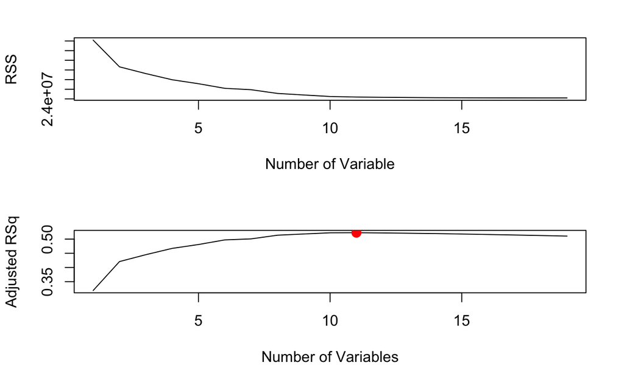

```r
max_index <- which.max(reg.summary$adjr2)
points(max_index, reg.summary$adjr2[max_index], col = 'red', cex = 2, pch = 20)
```

In a similar function we can plot the $C_p$ and BIC statistics, and indicate the models with the smallest statistic using `which.min()`

```r
par(mfrow = c(2,1))
plot(reg.summary$cp, xlab = "Number of Variables", ylab = "Cp", type = 'l')
min_index <- which.min(reg.summary$cp)
points(min_index, reg.summary$cp[min_index], col = "red", cex = 2, pch = 20)
```

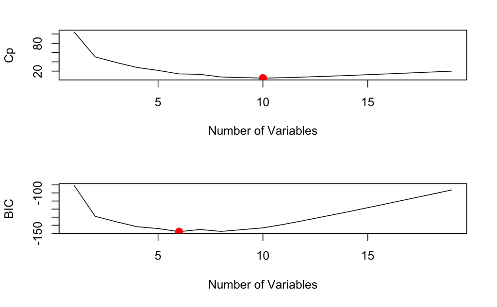

```r
min_index <- which.min(reg.summary$bic)
plot(reg.summary$bic, xlab = "Number of Variables", ylab = "BIC", type = 'l')
points(min_index, reg.summary$bic[min_index], col = "red", cex = 2, pch = 20)
```

### Forward and Backward Stepwise Selection

```r
regfit.fwd = regsubsets(Salary~., data = Hitters, nvmax = 19, method = "forward")
summary(regfit.fwd)
```

```
Subset selection object
Call: regsubsets.formula(Salary ~ ., data = Hitters, nvmax = 19, method = "forward")
19 Variables  (and intercept)
           Forced in Forced out
AtBat          FALSE      FALSE
Hits           FALSE      FALSE
HmRun          FALSE      FALSE
Runs           FALSE      FALSE
RBI            FALSE      FALSE
Walks          FALSE      FALSE
Years          FALSE      FALSE
CAtBat         FALSE      FALSE
CHits          FALSE      FALSE
CHmRun         FALSE      FALSE
CRuns          FALSE      FALSE
CRBI           FALSE      FALSE
CWalks         FALSE      FALSE
LeagueN        FALSE      FALSE
DivisionW      FALSE      FALSE
PutOuts        FALSE      FALSE
Assists        FALSE      FALSE
Errors         FALSE      FALSE
NewLeagueN     FALSE      FALSE
1 subsets of each size up to 19
Selection Algorithm: forward
          AtBat Hits HmRun Runs RBI Walks Years CAtBat CHits CHmRun CRuns CRBI CWalks
1  ( 1 )  " "   " "  " "   " "  " " " "   " "   " "    " "   " "    " "   "*"  " "
2  ( 1 )  " "   "*"  " "   " "  " " " "   " "   " "    " "   " "    " "   "*"  " "
3  ( 1 )  " "   "*"  " "   " "  " " " "   " "   " "    " "   " "    " "   "*"  " "
4  ( 1 )  " "   "*"  " "   " "  " " " "   " "   " "    " "   " "    " "   "*"  " "
5  ( 1 )  "*"   "*"  " "   " "  " " " "   " "   " "    " "   " "    " "   "*"  " "
6  ( 1 )  "*"   "*"  " "   " "  " " "*"   " "   " "    " "   " "    " "   "*"  " "
7  ( 1 )  "*"   "*"  " "   " "  " " "*"   " "   " "    " "   " "    " "   "*"  "*"
8  ( 1 )  "*"   "*"  " "   " "  " " "*"   " "   " "    " "   " "    "*"   "*"  "*"
9  ( 1 )  "*"   "*"  " "   " "  " " "*"   " "   "*"    " "   " "    "*"   "*"  "*"
10  ( 1 ) "*"   "*"  " "   " "  " " "*"   " "   "*"    " "   " "    "*"   "*"  "*"
11  ( 1 ) "*"   "*"  " "   " "  " " "*"   " "   "*"    " "   " "    "*"   "*"  "*"
12  ( 1 ) "*"   "*"  " "   "*"  " " "*"   " "   "*"    " "   " "    "*"   "*"  "*"
13  ( 1 ) "*"   "*"  " "   "*"  " " "*"   " "   "*"    " "   " "    "*"   "*"  "*"
14  ( 1 ) "*"   "*"  "*"   "*"  " " "*"   " "   "*"    " "   " "    "*"   "*"  "*"
```

[output cut: 10 more lines]

```
5  ( 1 )  " "     "*"       "*"     " "     " "    " "
6  ( 1 )  " "     "*"       "*"     " "     " "    " "
7  ( 1 )  " "     "*"       "*"     " "     " "    " "
8  ( 1 )  " "     "*"       "*"     " "     " "    " "
9  ( 1 )  " "     "*"       "*"     " "     " "    " "
10  ( 1 ) " "     "*"       "*"     "*"     " "    " "
11  ( 1 ) "*"     "*"       "*"     "*"     " "    " "
12  ( 1 ) "*"     "*"       "*"     "*"     " "    " "
13  ( 1 ) "*"     "*"       "*"     "*"     "*"    " "
14  ( 1 ) "*"     "*"       "*"     "*"     "*"    " "
15  ( 1 ) "*"     "*"       "*"     "*"     "*"    " "
16  ( 1 ) "*"     "*"       "*"     "*"     "*"    " "
17  ( 1 ) "*"     "*"       "*"     "*"     "*"    "*"
18  ( 1 ) "*"     "*"       "*"     "*"     "*"    "*"
19  ( 1 ) "*"     "*"       "*"     "*"     "*"    "*"
```

```r
regfit.bwd = regsubsets(Salary~., data = Hitters, nvmax = 19, method = "backward")
summary(regfit.bwd)
```

```
Subset selection object
Call: regsubsets.formula(Salary ~ ., data = Hitters, nvmax = 19, method = "backward")
19 Variables  (and intercept)
           Forced in Forced out
AtBat          FALSE      FALSE
Hits           FALSE      FALSE
HmRun          FALSE      FALSE
Runs           FALSE      FALSE
RBI            FALSE      FALSE
Walks          FALSE      FALSE
Years          FALSE      FALSE
CAtBat         FALSE      FALSE
CHits          FALSE      FALSE
CHmRun         FALSE      FALSE
CRuns          FALSE      FALSE
CRBI           FALSE      FALSE
CWalks         FALSE      FALSE
LeagueN        FALSE      FALSE
DivisionW      FALSE      FALSE
PutOuts        FALSE      FALSE
Assists        FALSE      FALSE
Errors         FALSE      FALSE
NewLeagueN     FALSE      FALSE
1 subsets of each size up to 19
Selection Algorithm: backward
          AtBat Hits HmRun Runs RBI Walks Years CAtBat CHits CHmRun CRuns CRBI CWalks
1  ( 1 )  " "   " "  " "   " "  " " " "   " "   " "    " "   " "    "*"   " "  " "
2  ( 1 )  " "   "*"  " "   " "  " " " "   " "   " "    " "   " "    "*"   " "  " "
3  ( 1 )  " "   "*"  " "   " "  " " " "   " "   " "    " "   " "    "*"   " "  " "
4  ( 1 )  "*"   "*"  " "   " "  " " " "   " "   " "    " "   " "    "*"   " "  " "
5  ( 1 )  "*"   "*"  " "   " "  " " "*"   " "   " "    " "   " "    "*"   " "  " "
6  ( 1 )  "*"   "*"  " "   " "  " " "*"   " "   " "    " "   " "    "*"   " "  " "
7  ( 1 )  "*"   "*"  " "   " "  " " "*"   " "   " "    " "   " "    "*"   " "  "*"
8  ( 1 )  "*"   "*"  " "   " "  " " "*"   " "   " "    " "   " "    "*"   "*"  "*"
9  ( 1 )  "*"   "*"  " "   " "  " " "*"   " "   "*"    " "   " "    "*"   "*"  "*"
10  ( 1 ) "*"   "*"  " "   " "  " " "*"   " "   "*"    " "   " "    "*"   "*"  "*"
11  ( 1 ) "*"   "*"  " "   " "  " " "*"   " "   "*"    " "   " "    "*"   "*"  "*"
12  ( 1 ) "*"   "*"  " "   "*"  " " "*"   " "   "*"    " "   " "    "*"   "*"  "*"
13  ( 1 ) "*"   "*"  " "   "*"  " " "*"   " "   "*"    " "   " "    "*"   "*"  "*"
14  ( 1 ) "*"   "*"  "*"   "*"  " " "*"   " "   "*"    " "   " "    "*"   "*"  "*"
```

[output cut: 10 more lines]

```
5  ( 1 )  " "     " "       "*"     " "     " "    " "
6  ( 1 )  " "     "*"       "*"     " "     " "    " "
7  ( 1 )  " "     "*"       "*"     " "     " "    " "
8  ( 1 )  " "     "*"       "*"     " "     " "    " "
9  ( 1 )  " "     "*"       "*"     " "     " "    " "
10  ( 1 ) " "     "*"       "*"     "*"     " "    " "
11  ( 1 ) "*"     "*"       "*"     "*"     " "    " "
12  ( 1 ) "*"     "*"       "*"     "*"     " "    " "
13  ( 1 ) "*"     "*"       "*"     "*"     "*"    " "
14  ( 1 ) "*"     "*"       "*"     "*"     "*"    " "
15  ( 1 ) "*"     "*"       "*"     "*"     "*"    " "
16  ( 1 ) "*"     "*"       "*"     "*"     "*"    " "
17  ( 1 ) "*"     "*"       "*"     "*"     "*"    "*"
18  ( 1 ) "*"     "*"       "*"     "*"     "*"    "*"
19  ( 1 ) "*"     "*"       "*"     "*"     "*"    "*"
```